# Non-native English essays disproportionately flagged as AI

Author: Michael Song

This notebook analyzes whether essays written by non-native English speakers are more likely to be falsely flagged as AI compared to native English speakers. Data for this analysis is taken from a 2023 edition of Tidy Tuesday, and is based off of a study done here

This study mainly serves as a way for me to learn some more modern R packages in the tidyverse, such as readr, dplyr, and ggplot2.

```r
library(readr)
library(dplyr)
library(ggplot2)
```

```r
detectors <- readr::read_csv('https://raw.githubusercontent.com/rfordatascience/tidytuesday/main/data/2023/2023-07-18/detectors.csv')
```

We can see that each row in our data represents one essay and instance of a detector. We also see that our data has 10 unique categories for the name column, with “Real TOEFL” being the only one corresponding to non-native human-written essays.

```r
print(detectors)
```

| kind | .pred_AI | .pred_class | detector | native | name | model | document_id | prompt | cat | right |
| --- | --- | --- | --- | --- | --- | --- | --- | --- | --- | --- |
| Human | 9.999942e-01 | AI | Sapling | No | Real TOEFL | Human | 497 | NA | real (non-native) | FALSE |
| Human | 8.281448e-01 | AI | Crossplag | No | Real TOEFL | Human | 278 | NA | real (non-native) | FALSE |
| Human | 2.137460e-04 | Human | Crossplag | Yes | Real College Essays | Human | 294 | NA | real (native) | TRUE |
| AI | 0.000000e+00 | Human | ZeroGPT | NA | Fake CS224N - GPT3 | GPT3 | 671 | Plain | fake | FALSE |
| AI | 1.784091e-03 | Human | OriginalityAI | NA | Fake CS224N - GPT3, PE | GPT4 | 717 | Elevate using technical | fake | FALSE |
| Human | 1.782710e-04 | Human | HFOpenAI | Yes | Real CS224N | Human | 855 | NA | real (native) | TRUE |
| AI | 9.915876e-01 | AI | HFOpenAI | NA | Fake CS224N - GPT3 | GPT3 | 533 | Plain | fake | TRUE |
| AI | 2.260207e-02 | Human | Crossplag | NA | Fake CS224N - GPT3, PE | GPT4 | 484 | Elevate using technical | fake | FALSE |
| Human | 0.000000e+00 | Human | ZeroGPT | Yes | Real CS224N | Human | 781 | NA | real (native) | TRUE |
| Human | 9.999993e-01 | AI | Sapling | No | Real TOEFL | Human | 460 | NA | real (non-native) | FALSE |

[output cut: 990 more lines]

```r
print(detectors$name %>% unique() %>% length())
```

```
[1] 10
```

```r
print(detectors$name %>% unique())
```

```
 [1] "Real TOEFL"                                   "Real College Essays"
 [3] "Fake CS224N - GPT3"                           "Fake CS224N - GPT3, PE"
 [5] "Real CS224N"                                  "US 8th grade essay"
 [7] "Fake TOEFL - GPT4 - PE"                       "Fake College Essays - GPT3"
 [9] "US 8th grade essay - GPT simplify"            "Fake College Essays - GPT3 Prompt Engineered"
```

We want to create a separate column/flag to denote whether an essay is ai, human (native), or human (non-native) for future analysis. We also want to create a flag for whether the detector flagged the essay correctly or incorrectly.

```r
detectors <- detectors %>%
  mutate(
    cat = case_when(
      kind == "AI" ~ "fake",
      native == "Yes" ~ "real (native)",
      TRUE ~ "real (non-native)"),
    right = case_when(kind == .pred_class ~ TRUE, TRUE ~ FALSE)
  )
```

We can visualize the original categories and our aggregate cat column to see the spread of observations.

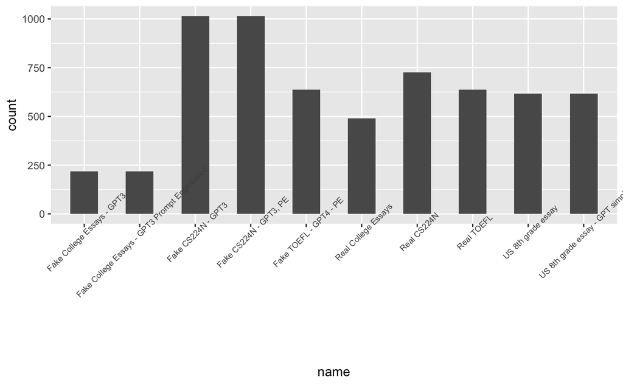

```r
ggplot(detectors, aes(x = name)) +
  geom_bar(width=0.5) +
  theme(axis.text.x  = element_text(angle=45, size = 7))
```

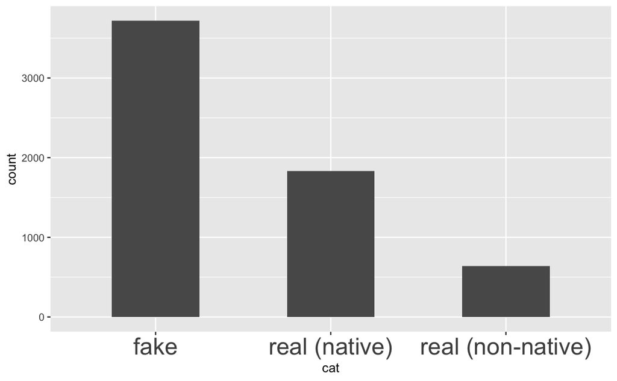

```r
ggplot(detectors, aes(x = cat)) +
  geom_bar(width=0.5) +
  theme(axis.text.x  = element_text(size = 20))
```

We can see from the above charts that most of the observations come from AI-generated data.

## Analysis

First, lets check the accuracy of our detectors without differentiating between native and non-native human essays

```r
accuracy <- group_by(detectors, detector) %>% summarise(accuracy = sum(right) / n())
mean_accuracy <- mean(accuracy$accuracy)
print(accuracy)
print(mean_accuracy)
```

[output not shown]

Lets go ahead and compare the likelihood that a human (native) essay is flagged as AI compared to a human (non-native) essay

```r
human.native <- filter(detectors, cat == "real (native)")
human.non.native <- filter(detectors, cat == "real (non-native)")
```

```r
# getting fraction of native/non-native essays that are flagged as AI
native.flagged <- human.native %>% summarize(flagged = 1 - sum(right) / n())
non.native.flagged <- human.non.native %>% summarize(flagged = 1 - sum(right) / n())
print(native.flagged %>% pull)
print(non.native.flagged %>% pull)
```

[output not shown]

To formally test whether these proportions significantly differ, we can do a two-proportion z test

```r
test.results <- prop.test(x = c(sum(!human.native$right), sum(!human.non.native$right)), n = c(nrow(human.native), nrow(human.non.native)))
print(test.results)
```

[output not shown]

Let’s check if this is also true for each individual detector, or if this only happens with some detectors.

```r
human.native.grouped <- group_by(human.native, detector) %>% summarise(x1 = (sum(!right)), n1 = n())
human.non.native.grouped <- group_by(human.non.native, detector) %>% summarise(x2 = (sum(!right)), n2 = n())

getP <- function(x1, n1, x2, n2, name) { # function that just returns the p value and detector name for each test
  result <- prop.test(x = c(x1, x2), n = c(n1, n2))
  return(c(name, result$p.value))
}

ps <- left_join(human.native.grouped, human.non.native.grouped, by = "detector") %>% mutate(p = pmap(list(x1, n2, x2, n2, detector), getP))

ps <- ps$p
ps <- as_tibble(do.call(rbind, ps))
print(ps)
```

[output not shown]

To wrap up, we can bookend our notebook with some analysis on the reliability of AI detectors in general.

```r
print(sum(!human.native$right) / nrow(human.native))
```

[output not shown]

```r
ai.only <- detectors %>% filter(kind == "AI")

print(sum(!ai.only$right) / nrow(ai.only))
```

[output not shown]

This can be graphed, too, to compare our three categories of AI, human (native), and human (non-native)

```r
final <- detectors %>% group_by(cat) %>% summarise(inaccuracy = (sum(!right) / n()))
ggplot(final, aes(x = cat, y = inaccuracy)) +
  geom_col(width=0.5) +
  theme(axis.text.x  = element_text(size = 20))
```

[output not shown]

# Conclusions given this data:

- In general, AI detectors are currently not reliable ways to detect AI-written work
- Across all detectors, human-written essays written by non-native English speakers are much more likely to be incorrectly flagged as AI-generated compared to human-written essays written by native English speakers
- AI detectors are only accurate in identifying human-written essays written by native English speakers